# A3: SPL Library Checkouts

Duyen T Nguyen

### Summary Information

```
## # A tibble: 99,545 × 2
##    Title                                                                     avg
##    <chr>                                                                   <dbl>
##  1 --And justice for all [sound recording] / Metallica.                     10
##  2 --and justice for all / Columbia Pictures ; a Joe Wizan presentation ;…  11.7
##  3 --And then you die of dysentery : lessons in adulting from The Oregon …  11
##  4 !Esperar no es fácil! / por Mo Willems ; adaptado al español por F. Is…  10.5
##  5 !Estamos en un libro! / por Mo Willems ; adaptado al español por F. Is…  11.3
##  6 ¡¡Manu!! / Kelly Fernández.                                              12.6
##  7 ¡Cuba! : recipes and stories from the Cuban kitchen / Dan Goldberg, An…  10
##  8 ¡Dormiré la siesta! / por Mo Williams ; adaptado al español por F. Isa…  10
##  9 ¡Es la hora de los esqueletos! = it's skeleton time! / adaptado por / …  11
## 10 ¡Hola Papi! : how to come out in a Walmart parking lot and other life …  12
## # … with 99,535 more rows
```

### The Dataset

- Who collected/published the data?  
  The data is collected and published by the Seattle Public Library.
- What are the parameters of the data (dates, number of checkouts, kinds of books, etc.)? The parameters of this data sets are:
  1. UsageClass Denotes if item is “physical” or “digital
  2. CheckoutType Denotes the vendor tool used to check out the item.
  3. MaterialType Describes the type of item checked out (examples: book, song movie, music, magazine)
  4. CheckoutYear  
     The 4-digit year of checkout for this record.
  5. CheckoutMonth  
     The month of checkout for this record.
  6. Checkouts  
     A count of the number of times the title was checked out within the “Checkout Month”.
  7. Title  
     The full title and subtitle of an individual item
  8. ISBN  
     A comma separated list of ISBNs associated with the item record for the checkout.
  9. Creator  
     The author or entity responsible for authoring the item.
  10. Subjects  
      The subject of the item as it appears in the catalog
  11. Publisher The publisher of the title
  12. PublicationYear  
      The year from the catalog record in which the item was published, printed, or copyrighted.
- How was the data collected or generated? The data monthly-counted for any items, physical and digital, that was checked out at least 10 times from SPL over the period from 20217 to 02/2023.
- Why was the data collected? The data was collected for community use.
- What, if any, ethical questions do you need to consider when working with this data? When working with this data, we must considered that this data only included works from any author that is feature in SPL. We must also considered that the same works may have been organized under different title and version, and the checkout number might be miscounted.
- What are possible limitations or problems with this data? (at least 200 words) One limitation this data set has is that it is only from 2017 to Feb of 2023, so it has yet to be fully annual. For example, when we were trying to see the annual trend of physical books checked out, we saw a huge drop between 2022 and 2023 (approximately a 90% drop), but one may fail to realize that this is only up-to-date for Feb 2023, so that number is yet to be accurate. Another challenge is when counting the average or total number of checkouts for each item, some items are the same work but in different forms (i.e. same work but physical books vs digital ebooks). So if we are trying to see, let’s say, how often a particular creator was being checked out, we might run the risk of overcounting the same work of that creator twice between the physical and digital versions. This is also a really big data set, and despite us filtering out the average number of checkouts for each item, it is still a lot of data to go through to see the general trend of checking out just by looking at the data table. When searching for checkouts with the series Berserk, I noticed the title section was very messy. It has weird capitalization and some odds punctuation, which can also be setbacks when organizing the data.

### First Trends Over Time Chart

I want to see the trend of average checkouts over the years for each month of book, ebook, and audio book. Using a line chart, we can see that the number of checkouts for book is overall lower than that of ebook and audiobook. In other words, the digital mediums seems to be more popular than its physical counter part. Audiobook and ebook have around the same average, but ebook tend to be more flat throughout the 12 months, while Audiobook seems to have a bump around June. It is worth to note that our y-axis is scaled from 20 to ~27, which make the gap between book and ebook/audiobook seems larger.

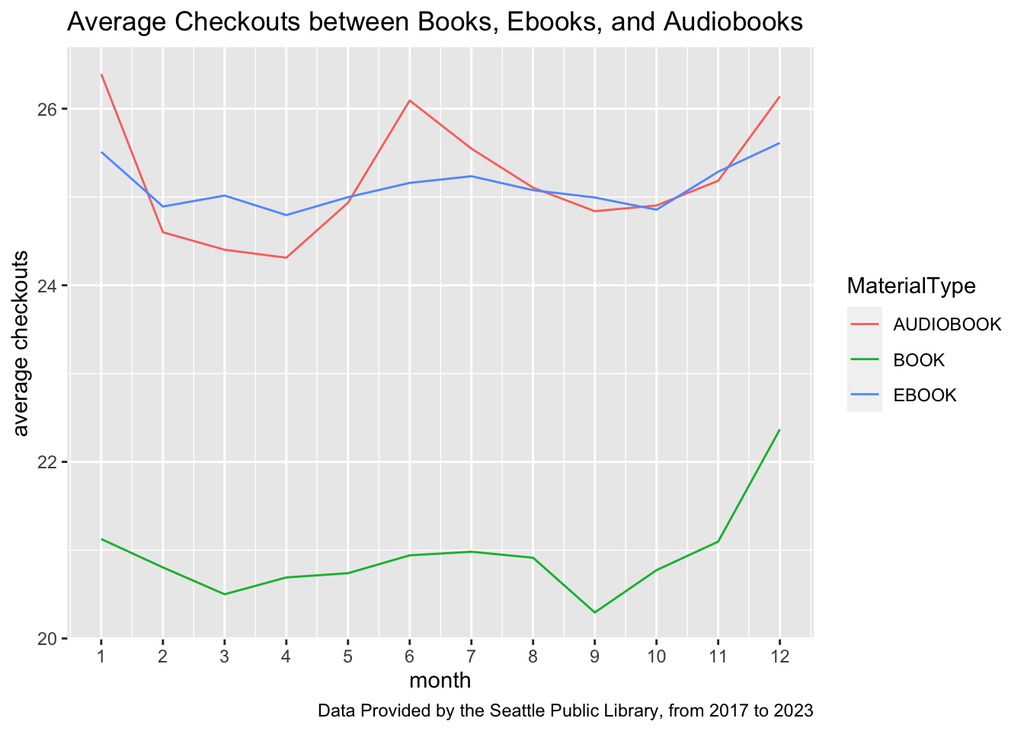

### Second Trends Over Time Chart

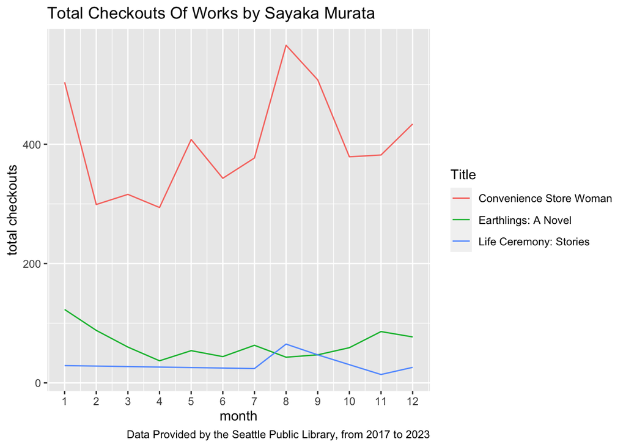

### Your Choice

I choose to use a line chart to look at the trends in different type of tool used for checkouts over the years. From the chart, it seems like between 2017 and 2019, Zinio was the most popular tool use, in fact, at some point, is 3 times as popular than other tools. However, after 2019, it was no longer documented to be used. Freegal and Hoopla was no longer documented after 2018, while Horizon and OverDrive went on to even current time, both steadily went on, with OverDrive being slightly more popular on average.

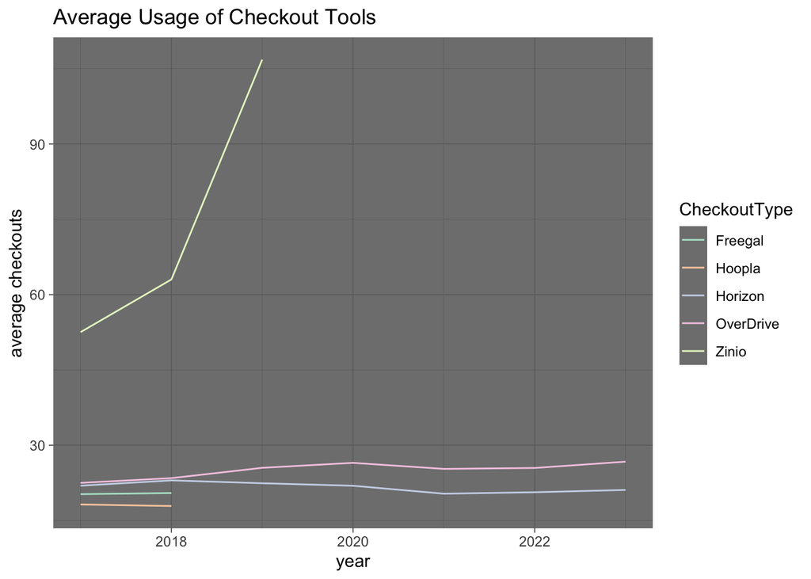